# DATS6101 Group Project: Predicting Heart Attacks

Jonathan Giguere, Jesse Borg, Ese Emuraye, Sarah Gates

December 11th 2019

## Introduction

For project two, our group used the Behavior Risk Factor Surveillance System (BRFSS) data from the 2013 survey. This data is collected by the CDC from all 50 states via landline phone and cellular phone covering a variety of health related topics. Generalizability is limited to those in the population with access to a landline or cell phone as well as to those living in a private residence or college housing. These factors leave out individuals and households who fall outside of these conditions, which means that random sampling is not fully taking place. Sampling bias occurs in the form of non-response, indicated by the NA/null points that exist in the dataset.

Our goal is to analyze factors that we believe may be related to heart attacks. We will not assume causality in the EDA portion of our project. We will spend time in it exploring relationships between these variables. After this, we will build and analyze the effectiveness of building two models as they relate to classifying and possibly predicting the occurence of a heart attack in an individual. We will utilize the decision tree method for classification and logistic regression for prediction. We selected these methods because our data includes both categorica and numeric variables and needed flexible methods to be able to work with both types.

## Loading the Data

Start by loading the packages we know will be needed for the project. Then load the brfss 2013 data which is as an RData file as opposed to a csv.

```r
loadPkg('ggplot2')
loadPkg('dplyr')
loadPkg('usmap')
```

```
##
##  C:\Users\sjg27\AppData\Local\Temp\Rtmpw9N4MM\downloaded_packages
```

```r
loadPkg('viridis')
```

```r
load("brfss2013.RData")
```

## Cleaning the data

We started by choosing the variables which we think will be useful or the most interesting for this study and then renamed them to have more logical or descriptive names.

```r
# Choose which variables we want to keep

keeps <- c('X_state', 'imonth', 'genhlth', 'menthlth', 'hlthpln1', 'sleptim1', 'bphigh4', 'bpmeds', 'cholchk','toldhi2', 'cvdinfr4', 'cvdcrhd4', 'cvdstrk3', 'asthma3', 'asthnow', 'addepev2', 'chckidny', 'diabete3', 'veteran3', 'marital', 'educa', 'employ1', 'income2', 'weight2', 'sex', 'pregnant', 'diffwalk', 'smoke100', 'smokday2', 'stopsmk2', 'usenow3', 'alcday5', 'avedrnk2', 'drnk3ge5', 'fruit1', 'fvgreen', 'exerany2', 'prediab1', 'qlmentl2', 'qlstres2', 'drvisits', 'ssbsugar', 'cvdasprn', 'scntwrk1','X_ageg5yr')

brfss_reduced <- brfss2013[keeps]
```

```r
# Rename the variables to be more descriptive


new_names <- c('state', 'month', 'gen_health', 'mental_health', 'health_coverage', 'sleep_time', 'high_bp', 'bp_meds', 'time_since_cholcheck','told_high_chol', 'heart_attack', 'angina', 'stroke', 'asthma', 'has_asthma_now', 'depression', 'kidney_disease', 'diabetes', 'veteran', 'marital_status', 'education_level', 'employment_status', 'income', 'weight', 'sex', 'pregnant', 'difficulty_walk', 'smoke_100', 'freq_smoke', 'stop_smoke_year', 'smokeless_tabac', 'alc_past_30', 'alc_perday_30', 'binge_alc', 'fruit_freq', 'green_veg_freq', 'exercise_30', 'prediabetes', 'depressed_30', 'anxious_30', 'dr_visits_year', 'soda_freq', 'aspirin_daily', 'work_hours_week','age5yr_bucket')

names(brfss_reduced) <- new_names
```

Once this was done, check to see how many missing values for each column.

```
##                state               weight                month
##                    0                    0                    3
##                  sex              veteran             diabetes
##                    7                  746                  832
##              high_bp               stroke               asthma
##                 1420                 1467                 1559
##       kidney_disease      health_coverage           gen_health
##                 1721                 1904                 1985
##      education_level           depression         heart_attack
##                 2274                 2289                 2587
##    employment_status       marital_status               angina
##                 3386                 3420                 4423
##        age5yr_bucket           sleep_time        mental_health
##                 4730                 7387                 8627
##      difficulty_walk      smokeless_tabac            smoke_100
##                12764                14018                14920
##          alc_past_30           fruit_freq          exercise_30
##                19644                33798                34029
##       green_veg_freq               income       told_high_chol
##                35157                71426                71662
## time_since_cholcheck       dr_visits_year          prediabetes
##                73178               154152               257913
##            binge_alc        alc_perday_30           freq_smoke
##               260444               260590               276983
##              bp_meds        aspirin_daily            soda_freq
##               293201               355557               388580
##             pregnant      stop_smoke_year       has_asthma_now
##               414790               415421               426435
##      work_hours_week         depressed_30           anxious_30
##               459413               491284               491288
```

Since there are some columns with a lot of missing values, we decided to drop the ones with more than 100,000 missing entries.

```r
# Drop the variables which have too many missing values

brfss_reduced_drops <- subset(brfss_reduced, select = -c(dr_visits_year, prediabetes, binge_alc, alc_perday_30, freq_smoke, bp_meds, aspirin_daily, soda_freq, pregnant, stop_smoke_year, has_asthma_now, work_hours_week, depressed_30, anxious_30))
```

We then removed the rows which have any missing values so that the data we have is complete.

```r
# Remove the rows which have na values in any of the remaining variables

brfss_complete <- na.omit(brfss_reduced_drops)
```

Inspect the dataframe after the missing values have been removed, which shows that there are still over 300,000 observations and 31 variables. This is more than enough data for what we need.

```
## 'data.frame':    313247 obs. of  31 variables:
##  $ state               : Factor w/ 55 levels "0","Alabama",..: 2 2 2 2 2 2 2 2 2 2 ...
##  $ month               : Factor w/ 12 levels "January","February",..: 1 1 1 2 3 3 4 4 4 6 ...
##  $ gen_health          : Factor w/ 5 levels "Excellent","Very good",..: 3 3 2 3 2 3 1 3 4 4 ...
##  $ mental_health       : int  0 2 0 2 0 0 0 0 0 1 ...
##  $ health_coverage     : Factor w/ 2 levels "Yes","No": 1 1 1 1 1 1 1 1 2 1 ...
##  $ sleep_time          : int  6 9 8 6 8 6 8 8 3 8 ...
##  $ high_bp             : Factor w/ 4 levels "Yes","Yes, but female told only during pregnancy",..: 3 3 3 1 1 1 3 3 1 1 ...
##  $ time_since_cholcheck: Factor w/ 4 levels "Within past year",..: 1 4 1 2 1 1 1 1 1 1 ...
##  $ told_high_chol      : Factor w/ 2 levels "Yes","No": 2 2 1 2 1 1 1 2 1 1 ...
##  $ heart_attack        : Factor w/ 2 levels "Yes","No": 2 2 2 2 2 2 2 2 1 2 ...
##  $ angina              : Factor w/ 2 levels "Yes","No": 2 2 2 2 2 1 2 2 2 2 ...
##  $ stroke              : Factor w/ 2 levels "Yes","No": 2 2 2 2 2 2 2 2 2 2 ...
##  $ asthma              : Factor w/ 2 levels "Yes","No": 2 2 2 1 2 2 2 2 1 1 ...
##  $ depression          : Factor w/ 2 levels "Yes","No": 1 1 2 2 2 2 2 2 1 1 ...
```

[output cut: 19 more lines]

For the factors, we want to change some of the variable factors to be more intuitive/descriptive, start by inspecting the levels for the factors we might want to change.

```r
# Check the levels for some varibles

levels(brfss_complete$high_bp)
```

```
## [1] "Yes"
## [2] "Yes, but female told only during pregnancy"
## [3] "No"
## [4] "Told borderline or pre-hypertensive"
```

```r
levels(brfss_complete$employment_status)
```

```
## [1] "Employed for wages"               "Self-employed"
## [3] "Out of work for 1 year or more"   "Out of work for less than 1 year"
## [5] "A homemaker"                      "A student"
## [7] "Retired"                          "Unable to work"
```

```r
levels(brfss_complete$smokeless_tabac)
```

```
## [1] "Every day"  "Some days"  "Not at all"
```

```r
levels(brfss_complete$diabetes)
```

```
## [1] "Yes"
## [2] "Yes, but female told only during pregnancy"
## [3] "No"
## [4] "No, pre-diabetes or borderline diabetes"
```

Change the yes/no factors to 1/0 for model purposes and change other factors in the variables above to make them better grouped.

```r
# Change the factor levels for the variables wwe feel would be better off changed

levels(brfss_complete$health_coverage)[levels(brfss_complete$health_coverage) == 'Yes'] <- 1
levels(brfss_complete$health_coverage)[levels(brfss_complete$health_coverage) == 'No'] <- 0

levels(brfss_complete$heart_attack)[levels(brfss_complete$heart_attack) == 'Yes'] <- 1
levels(brfss_complete$heart_attack)[levels(brfss_complete$heart_attack) == 'No'] <- 0

levels(brfss_complete$angina)[levels(brfss_complete$angina) == 'Yes'] <- 1
levels(brfss_complete$angina)[levels(brfss_complete$angina) == 'No'] <- 0

levels(brfss_complete$stroke)[levels(brfss_complete$stroke) == 'Yes'] <- 1
levels(brfss_complete$stroke)[levels(brfss_complete$stroke) == 'No'] <- 0

levels(brfss_complete$asthma)[levels(brfss_complete$asthma) == 'Yes'] <- 1
levels(brfss_complete$asthma)[levels(brfss_complete$asthma) == 'No'] <- 0

levels(brfss_complete$depression)[levels(brfss_complete$depression) == 'Yes'] <- 1
levels(brfss_complete$depression)[levels(brfss_complete$depression) == 'No'] <- 0

levels(brfss_complete$kidney_disease)[levels(brfss_complete$kidney_disease) == 'Yes'] <- 1
levels(brfss_complete$kidney_disease)[levels(brfss_complete$kidney_disease) == 'No'] <- 0

levels(brfss_complete$veteran)[levels(brfss_complete$veteran) == 'Yes'] <- 1
levels(brfss_complete$veteran)[levels(brfss_complete$veteran) == 'No'] <- 0

levels(brfss_complete$difficulty_walk)[levels(brfss_complete$difficulty_walk) == 'Yes'] <- 1
levels(brfss_complete$difficulty_walk)[levels(brfss_complete$difficulty_walk) == 'No'] <- 0

levels(brfss_complete$smoke_100)[levels(brfss_complete$smoke_100) == 'Yes'] <- 1
levels(brfss_complete$smoke_100)[levels(brfss_complete$smoke_100) == 'No'] <- 0

levels(brfss_complete$exercise_30)[levels(brfss_complete$exercise_30) == 'Yes'] <- 1
levels(brfss_complete$exercise_30)[levels(brfss_complete$exercise_30) == 'No'] <- 0

levels(brfss_complete$diabetes)[levels(brfss_complete$diabetes) == "Yes, but female told only during pregnancy"] <- 1
levels(brfss_complete$diabetes)[levels(brfss_complete$diabetes) == "No, pre-diabetes or borderline diabetes"  ] <- 0
levels(brfss_complete$diabetes)[levels(brfss_complete$diabetes) == 'Yes'] <- 1
levels(brfss_complete$diabetes)[levels(brfss_complete$diabetes) == 'No'] <- 0

levels(brfss_complete$high_bp)[levels(brfss_complete$high_bp) == "Yes, but female told only during pregnancy"] <- 1
levels(brfss_complete$high_bp)[levels(brfss_complete$high_bp) == "Told borderline or pre-hypertensive" ] <- 1
levels(brfss_complete$high_bp)[levels(brfss_complete$high_bp) == 'Yes'] <- 1
levels(brfss_complete$high_bp)[levels(brfss_complete$high_bp) == 'No'] <- 0

levels(brfss_complete$employment_status)[levels(brfss_complete$employment_status) == "Employed for wages" ] <- 'Employed'
levels(brfss_complete$employment_status)[levels(brfss_complete$employment_status) == "Out of work for 1 year or more" ] <- 'Unemployed'
levels(brfss_complete$employment_status)[levels(brfss_complete$employment_status) == "Out of work for less than 1 year" ] <- 'Unemployed'

levels(brfss_complete$smokeless_tabac)[levels(brfss_complete$smokeless_tabac) == "Every day" ] <- 1
levels(brfss_complete$smokeless_tabac)[levels(brfss_complete$smokeless_tabac) == "Some days" ] <- 1
levels(brfss_complete$smokeless_tabac)[levels(brfss_complete$smokeless_tabac) == "Not at all" ] <- 0
```

Inspect the structure of the dataframe with changed variables

```
## 'data.frame':    313247 obs. of  31 variables:
##  $ state               : Factor w/ 55 levels "0","Alabama",..: 2 2 2 2 2 2 2 2 2 2 ...
##  $ month               : Factor w/ 12 levels "January","February",..: 1 1 1 2 3 3 4 4 4 6 ...
##  $ gen_health          : Factor w/ 5 levels "Excellent","Very good",..: 3 3 2 3 2 3 1 3 4 4 ...
##  $ mental_health       : int  0 2 0 2 0 0 0 0 0 1 ...
##  $ health_coverage     : Factor w/ 2 levels "1","0": 1 1 1 1 1 1 1 1 2 1 ...
##  $ sleep_time          : int  6 9 8 6 8 6 8 8 3 8 ...
##  $ high_bp             : Factor w/ 2 levels "1","0": 2 2 2 1 1 1 2 2 1 1 ...
##  $ time_since_cholcheck: Factor w/ 4 levels "Within past year",..: 1 4 1 2 1 1 1 1 1 1 ...
##  $ told_high_chol      : Factor w/ 2 levels "Yes","No": 2 2 1 2 1 1 1 2 1 1 ...
##  $ heart_attack        : Factor w/ 2 levels "1","0": 2 2 2 2 2 2 2 2 1 2 ...
##  $ angina              : Factor w/ 2 levels "1","0": 2 2 2 2 2 1 2 2 2 2 ...
##  $ stroke              : Factor w/ 2 levels "1","0": 2 2 2 2 2 2 2 2 2 2 ...
##  $ asthma              : Factor w/ 2 levels "1","0": 2 2 2 1 2 2 2 2 1 1 ...
##  $ depression          : Factor w/ 2 levels "1","0": 1 1 2 2 2 2 2 2 1 1 ...
```

[output cut: 19 more lines]

## Exploratory Data Analysis

### Jonathan EDA

- Heart attacks and states?
- General health and effects on heart attack?
- Health coverage and heart attack?
- Sleep and heart attack?
- High BP and heart attack?

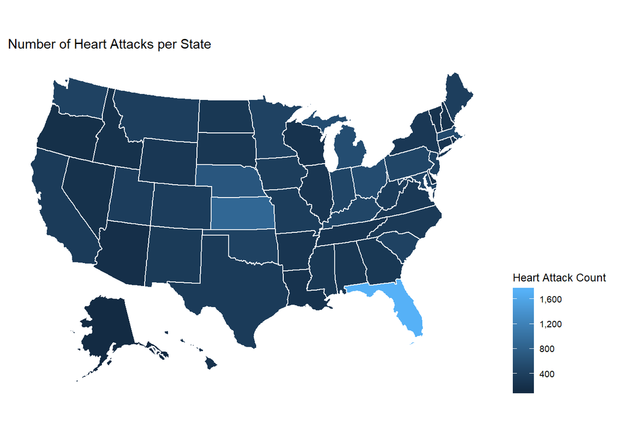

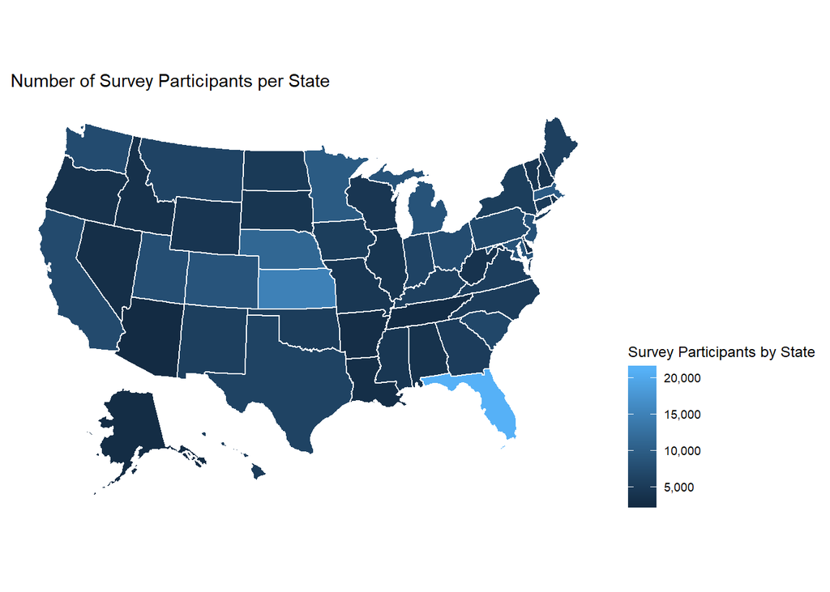

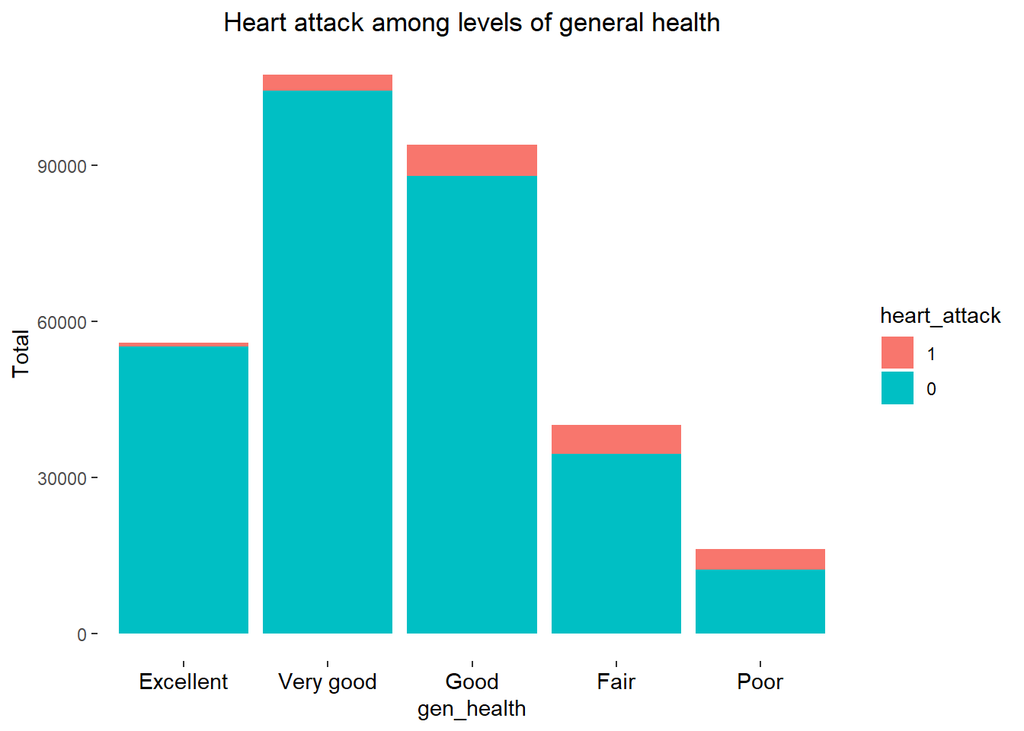

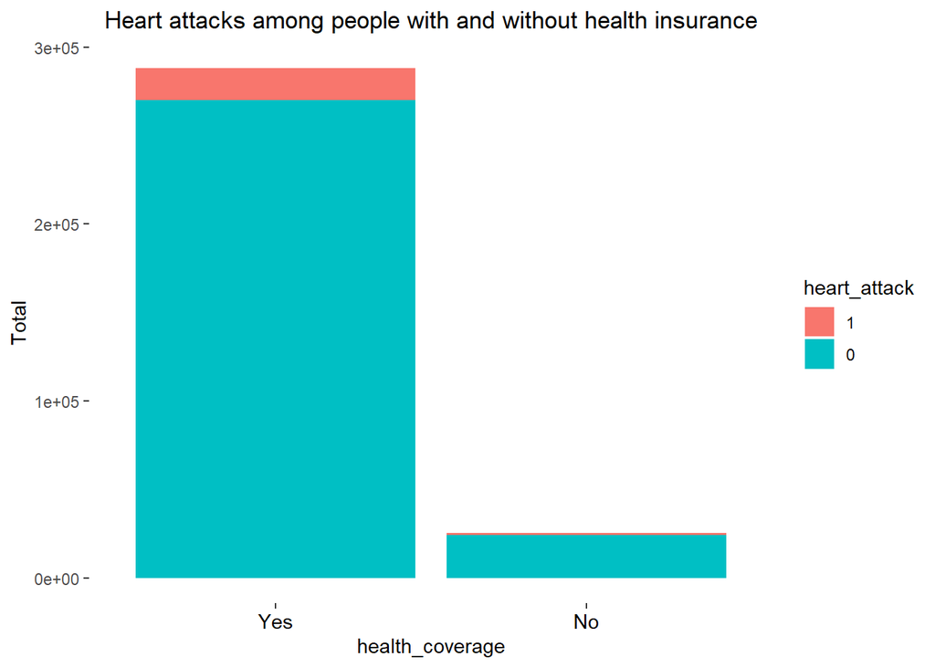

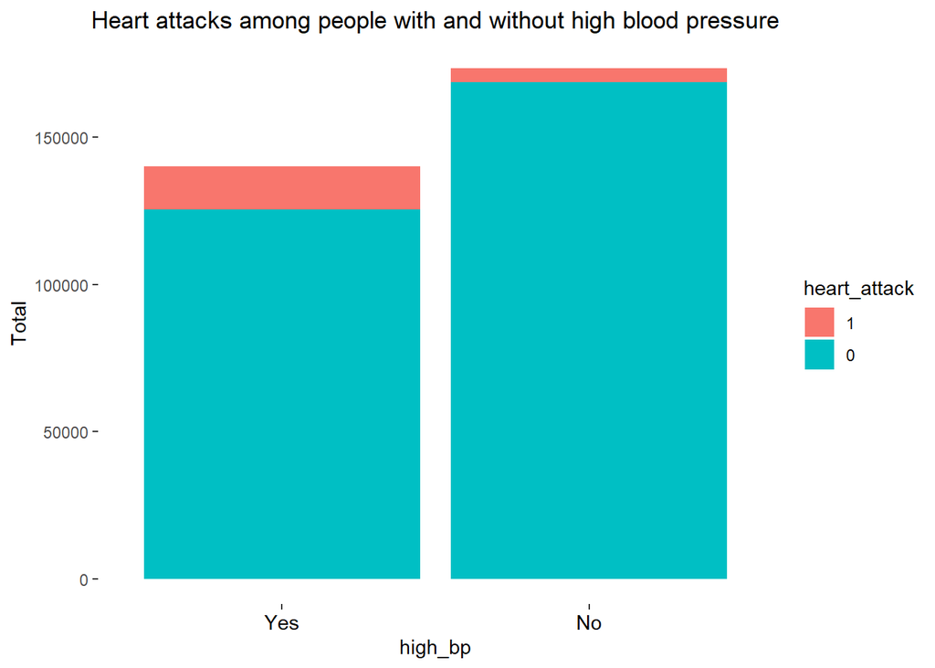

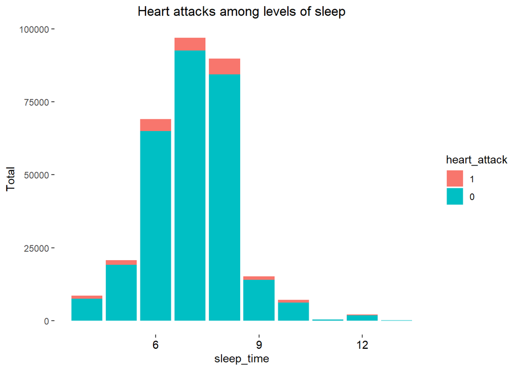

### Sarah EDA

Sarah’s EDA - Time since cholesterols check - Smoking - Angina - Depression - Kidney disease - Age

Cholesterol check

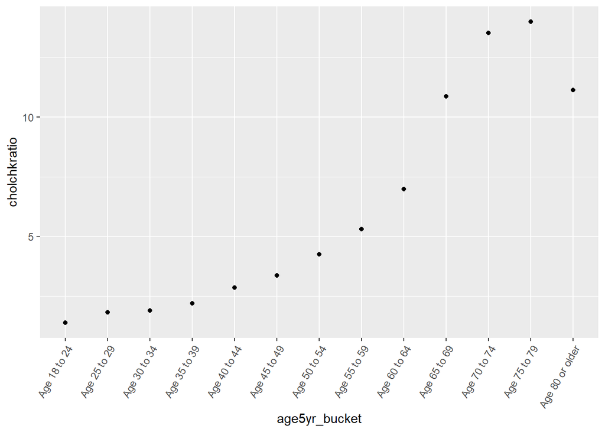

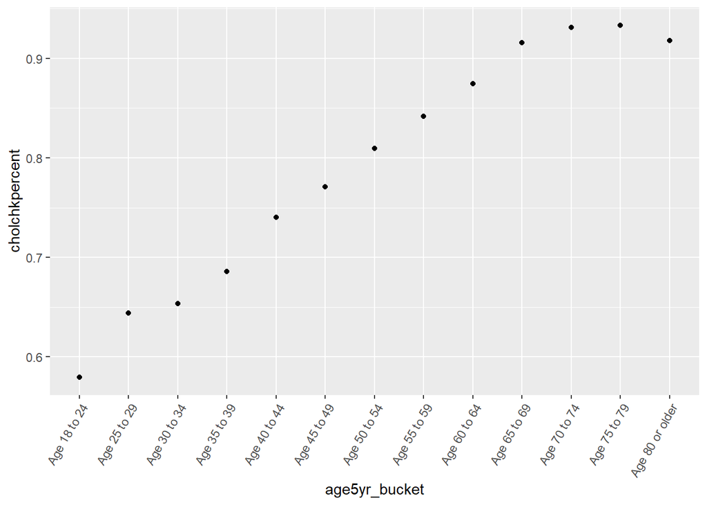

```
## # A tibble: 13 x 4
##    age5yr_bucket   cholchkratio cholchkpercent cholchkcount
##    <fct>                  <dbl>          <dbl>        <int>
##  1 Age 18 to 24            1.38          0.579          673
##  2 Age 25 to 29            1.81          0.644         1303
##  3 Age 30 to 34            1.89          0.654         2611
##  4 Age 35 to 39            2.19          0.686         4052
##  5 Age 40 to 44            2.85          0.740         6154
##  6 Age 45 to 49            3.36          0.771         9061
##  7 Age 50 to 54            4.24          0.809        14224
##  8 Age 55 to 59            5.31          0.842        18385
##  9 Age 60 to 64            6.98          0.875        20918
## 10 Age 65 to 69           10.9           0.916        20385
## 11 Age 70 to 74           13.5           0.931        15452
## 12 Age 75 to 79           14.0           0.933        10849
## 13 Age 80 or older        11.1           0.918        11393
```

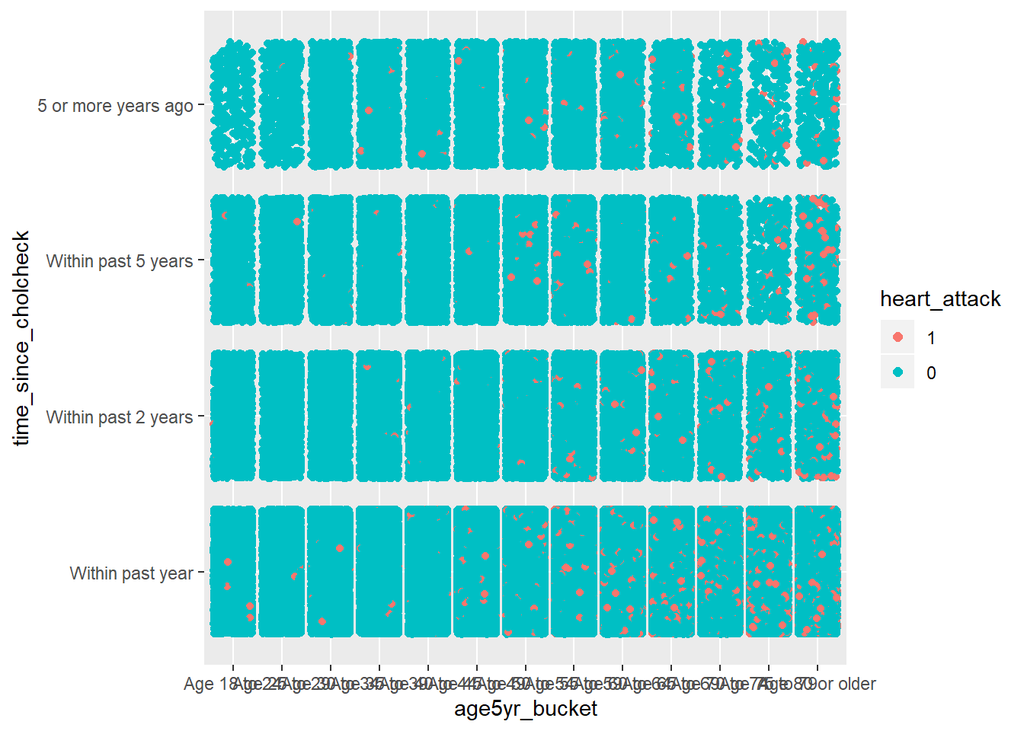

Smoking and heart attack - TRY BAR CHART

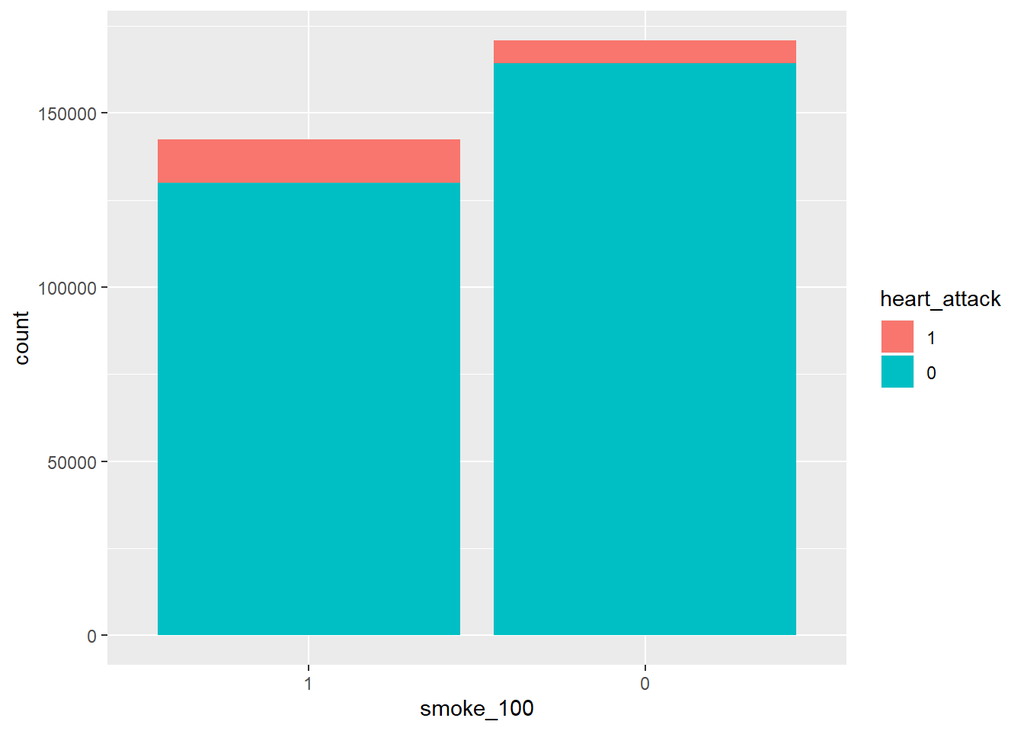

Angina - INTERESTING DISTRIBUTION, EXPLORE THIS FURTHER - BY AGE? BY GENDER?

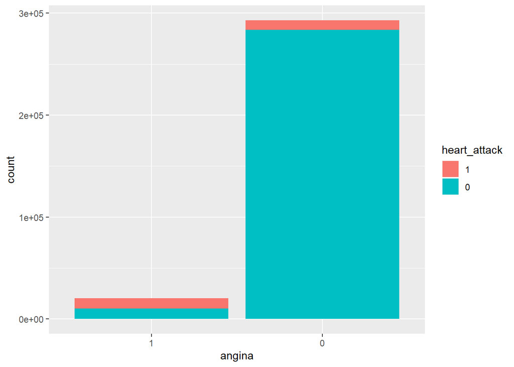

Depression

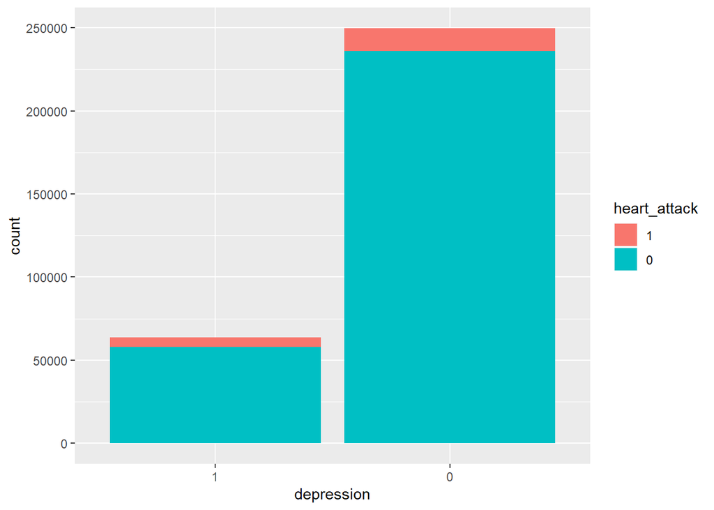

Kidney disease- maybe look at kidney disease vs heart attack at different age brackets AND between genders, side by side bar chart

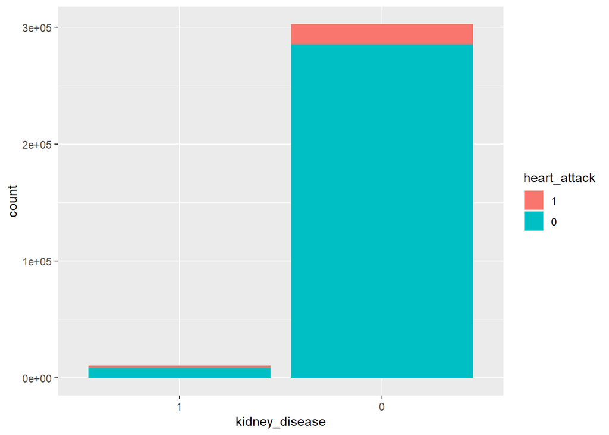

### Jesse EDA

- Smoking and heart attack?
- Smokeless tababcco and heart attack?
- Alcohol and heart attack?
- Fruit and heart attack?
- Veggies and heart attack?
- Exercise and heart attack?

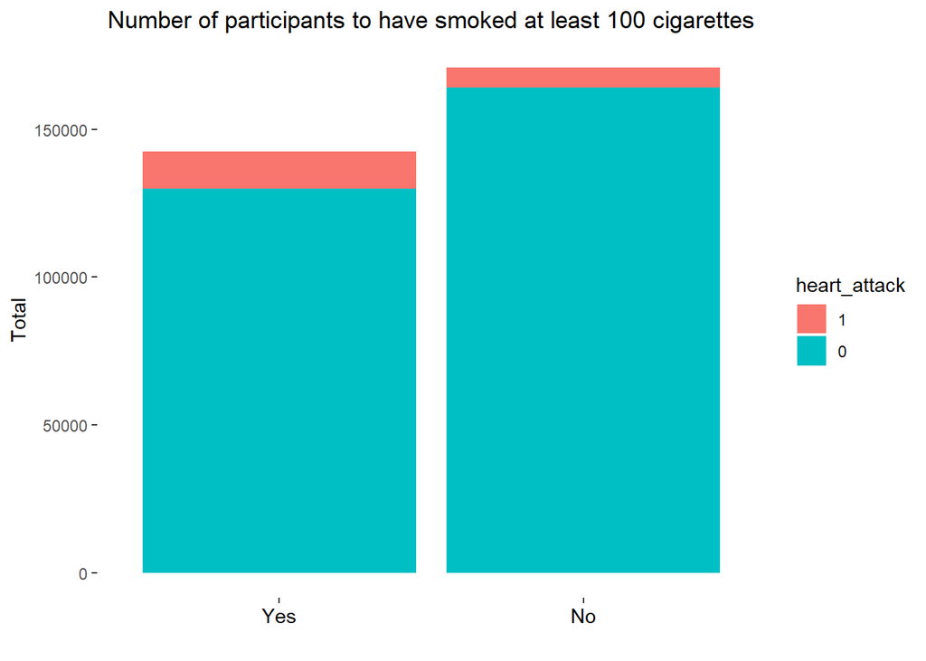

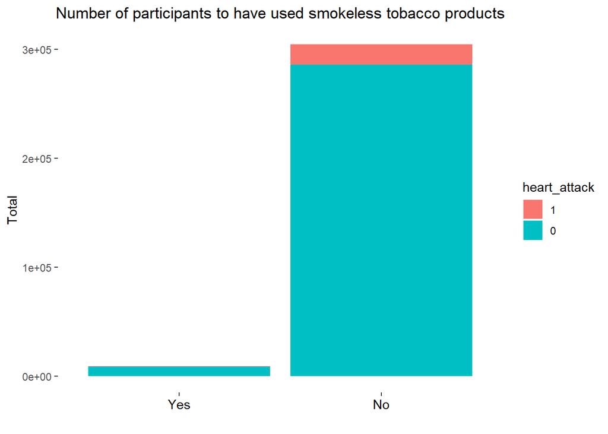

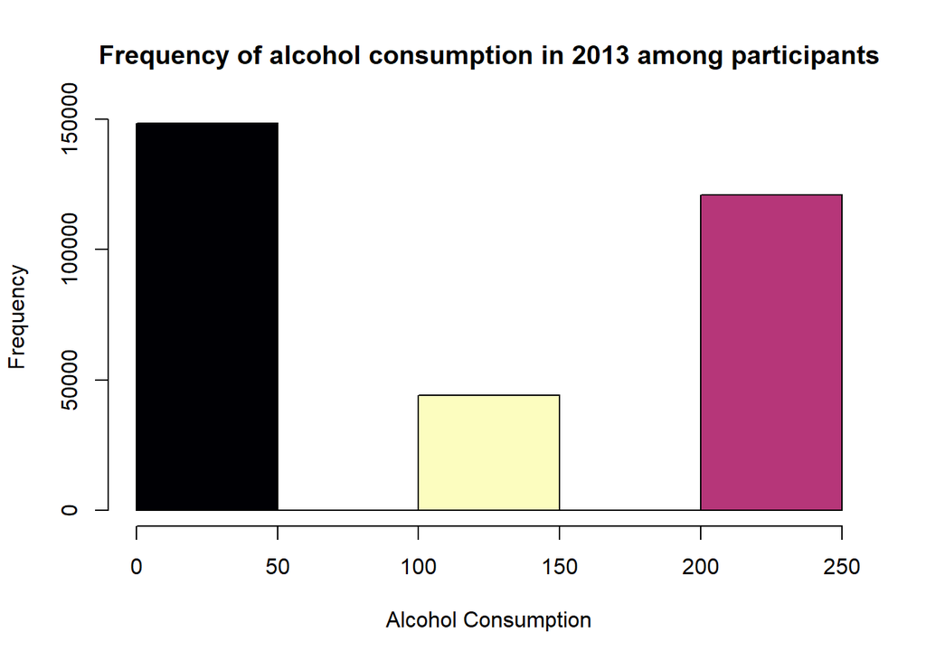

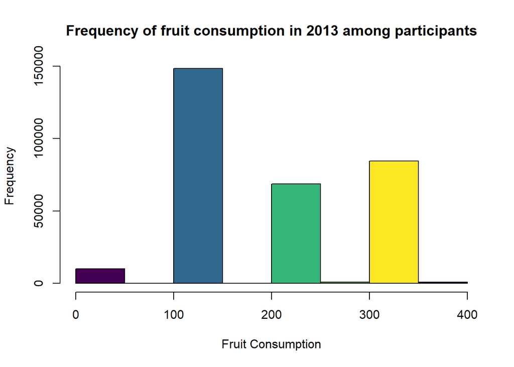

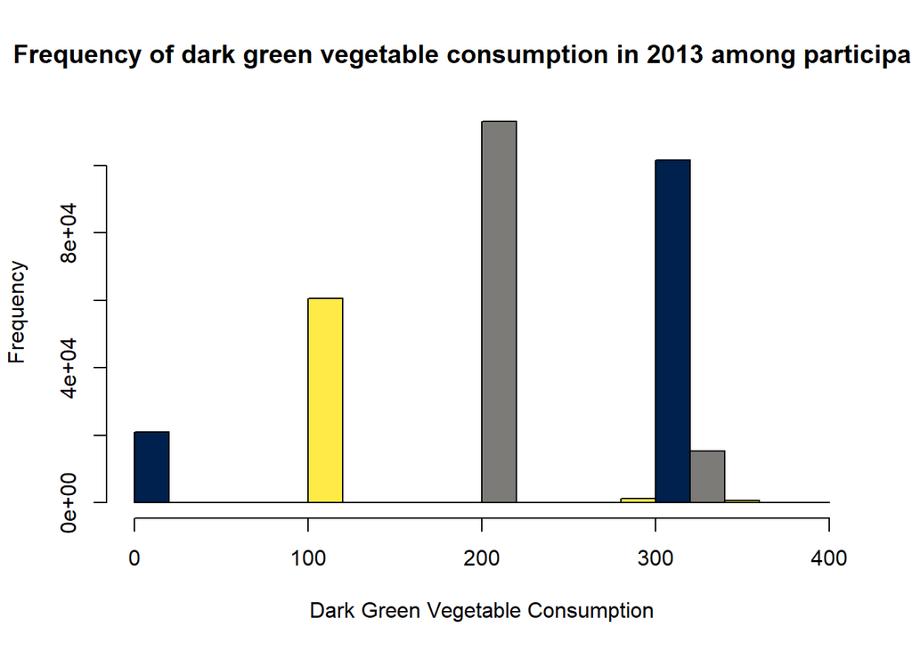

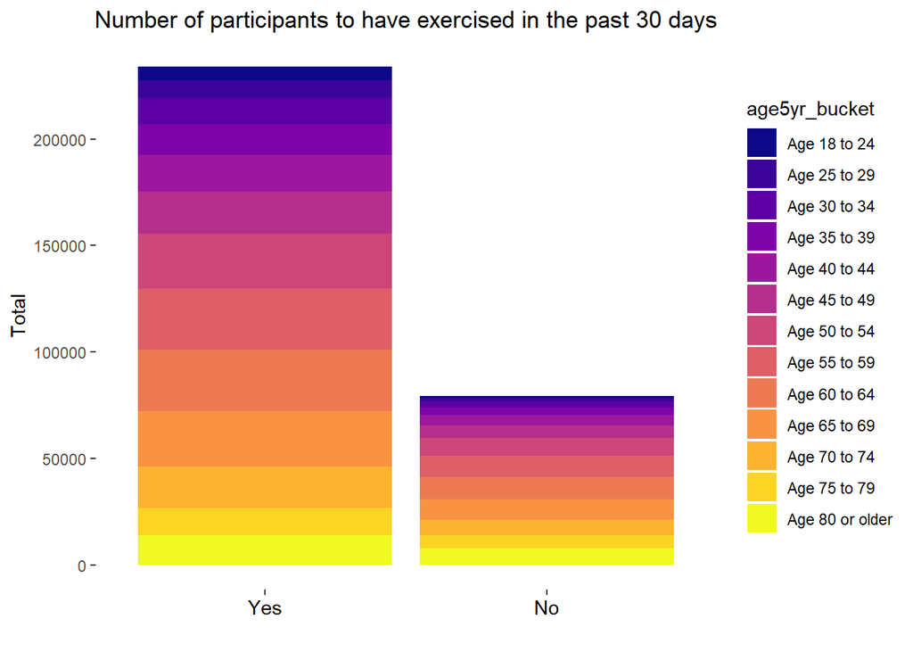

### Ese EDA

- Diabetes and heart attack?
- Employment status and heart attack?
- Income and heart attack?
- Weight and heart attack?
- Sex and heart attack?

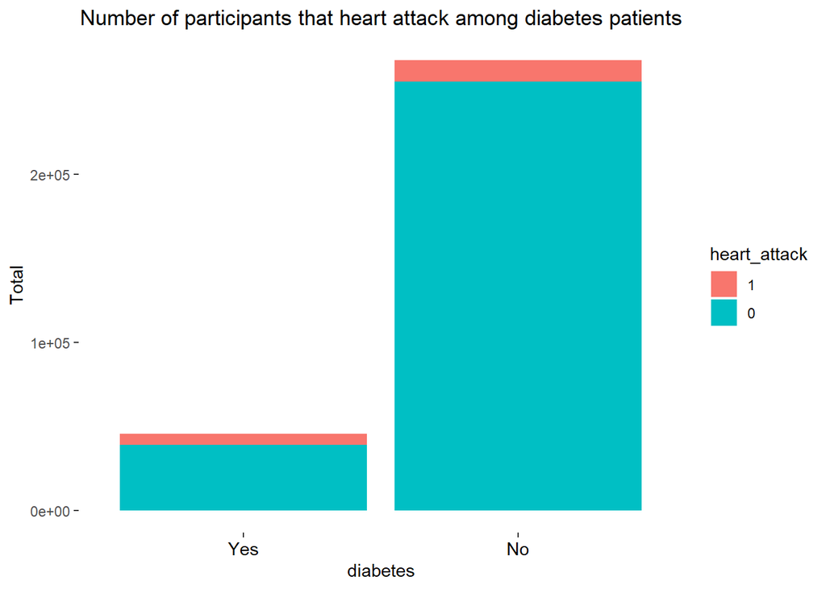

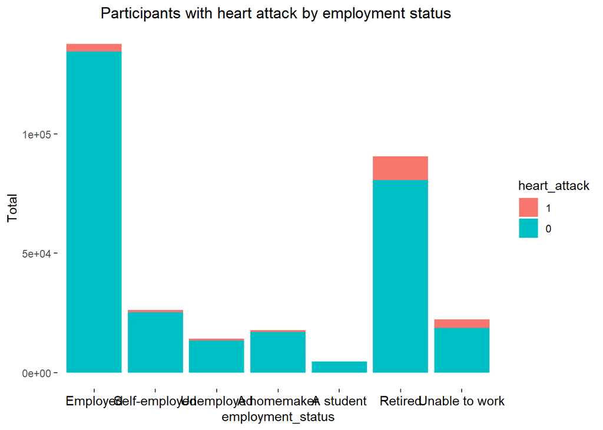

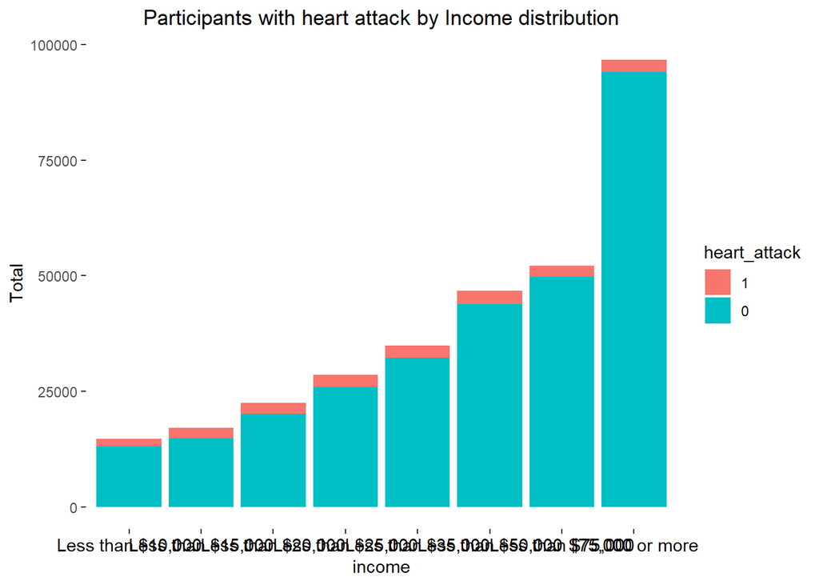

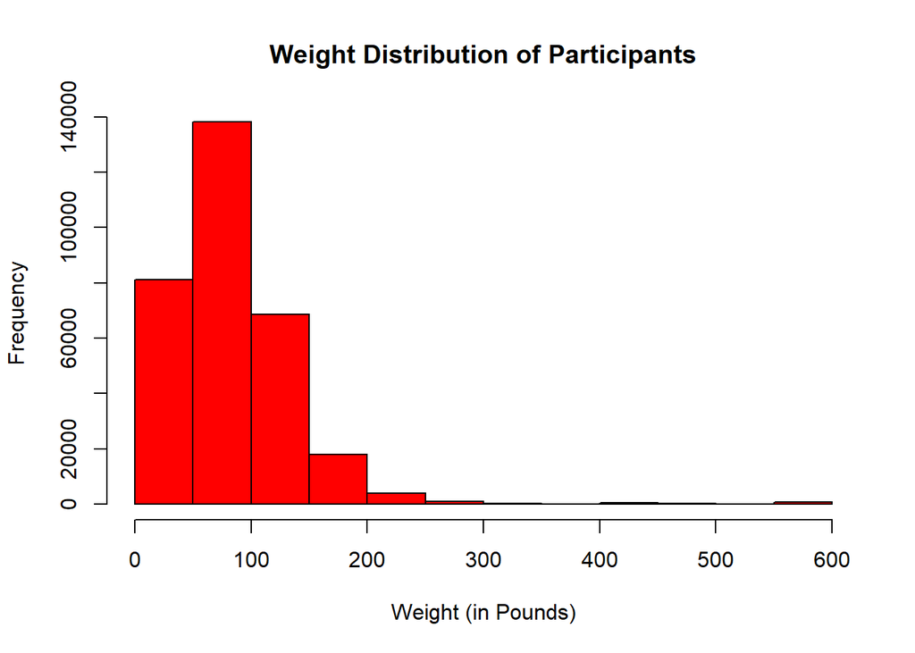

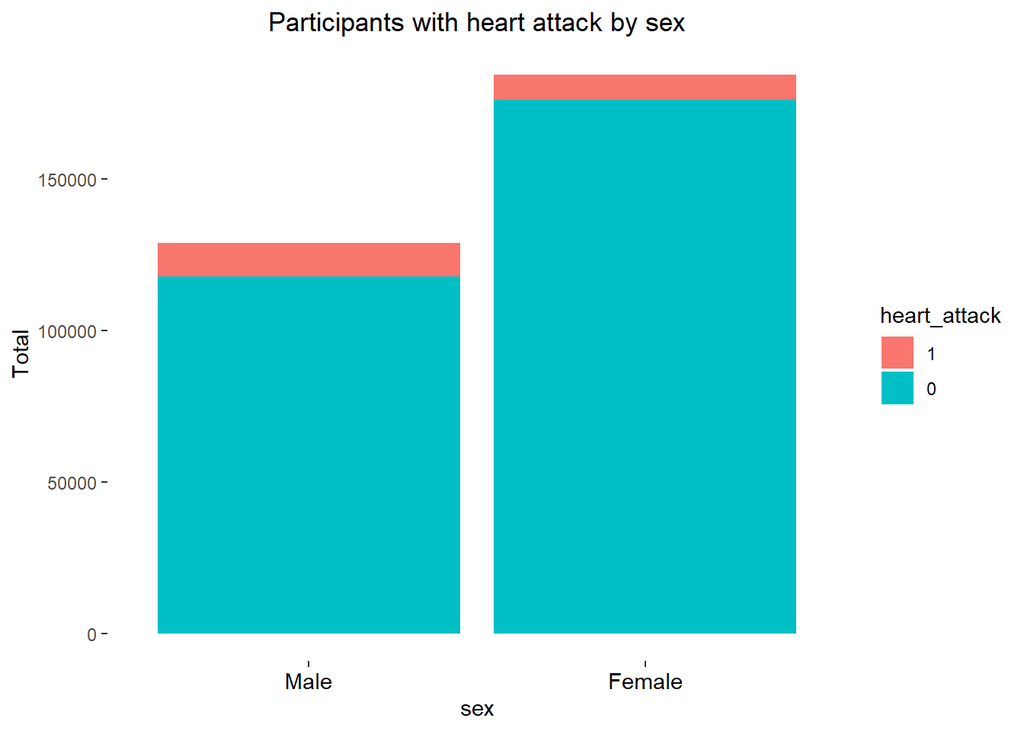

## Hypothesis Tests

### Chi-Squared Tests of Independence

Null Hypothesis: The two variables are independent.

Alternative Hypothesis: The two variables are dependent.

| Categorical Variable | Chi-Test P-value < 0.05? | Include? |
| --- | --- | --- |
| gen_health | TRUE | Yes |
| mental_health | TRUE | Yes |
| health_coverage | TRUE | Yes |
| high_bp | TRUE | Yes |
| time_since_cholcheck | TRUE | Yes |
| told_high_chol | TRUE | Yes |
| angina | TRUE | Yes |
| stroke | TRUE | Yes |
| ashtma | TRUE | Yes |
| depression | TRUE | Yes |
| kidney_disease | TRUE | Yes |
| diabetes | TRUE | Yes |
| veteran | TRUE | Yes |
| marital_status | TRUE | Yes |
| education_level | TRUE | Yes |
| employment_status | TRUE | Yes |
| income | TRUE | Yes |
| sex | TRUE | Yes |
| difficulty_walk | TRUE | Yes |
| smoke_100 | TRUE | Yes |
| smokeless_tabac | FALSE | No |
| exercise_30 | TRUE | Yes |
| age5yr_bucket | TRUE | Yes |

Based on the table above, we reject the null hypothesis for all variables except smokeless_tabac. At a 0.05 threshold, all categorical variables have a dependent relationship with heart_attack except smokeless_tabac. We will exclude smokeless_tabac in our models.

## Modeling

### Logistic Regression

NEED TO NARROW DOWN TRAINING SET?

```
##
## Call:
## glm(formula = heart_attack ~ sex + sleep_time + age5yr_bucket,
##     family = "binomial", data = heart_attack_training)
##
## Deviance Residuals:
##     Min       1Q   Median       3Q      Max
## -3.4457   0.1638   0.2893   0.4112   0.9183
##
## Coefficients:
##                               Estimate Std. Error z value Pr(>|z|)
## (Intercept)                   4.244441   0.194989  21.768  < 2e-16 ***
## sexFemale                     0.750423   0.018278  41.057  < 2e-16 ***
## sleep_time                    0.090663   0.006615  13.706  < 2e-16 ***
## age5yr_bucketAge 25 to 29     0.032448   0.251114   0.129  0.89718
## age5yr_bucketAge 30 to 34    -0.175686   0.225198  -0.780  0.43531
## age5yr_bucketAge 35 to 39    -0.574094   0.210890  -2.722  0.00648 **
## age5yr_bucketAge 40 to 44    -0.956717   0.201797  -4.741 2.13e-06 ***
## age5yr_bucketAge 45 to 49    -1.519778   0.195670  -7.767 8.03e-15 ***
## age5yr_bucketAge 50 to 54    -2.041870   0.192412 -10.612  < 2e-16 ***
## age5yr_bucketAge 55 to 59    -2.309215   0.191527 -12.057  < 2e-16 ***
## age5yr_bucketAge 60 to 64    -2.658383   0.190992 -13.919  < 2e-16 ***
## age5yr_bucketAge 65 to 69    -2.997593   0.190750 -15.715  < 2e-16 ***
## age5yr_bucketAge 70 to 74    -3.201668   0.190972 -16.765  < 2e-16 ***
## age5yr_bucketAge 75 to 79    -3.407033   0.191317 -17.808  < 2e-16 ***
## age5yr_bucketAge 80 or older -3.689601   0.190833 -19.334  < 2e-16 ***
## ---
## Signif. codes:  0 '***' 0.001 '**' 0.01 '*' 0.05 '.' 0.1 ' ' 1
##
## (Dispersion parameter for binomial family taken to be 1)
##
##     Null deviance: 102275  on 219305  degrees of freedom
## Residual deviance:  92138  on 219291  degrees of freedom
## AIC: 92168
##
## Number of Fisher Scoring iterations: 7
```